# Problem Set 5

Due date: 21 October

Please upload your completed assignment to the ELMs course site (under the assignments menu) and to your class Github repository. You need to upload both your Quarto document (with R code, as needed) and its rendered output (either as a PDF or HTML file).

**Total points: 25**

**Note**

23/25

```r
library(tidyverse)
library(skimr)
library(janitor)
library(ggsci)
library(RColorBrewer)
library(paletteer)
library(devtools)
library(polisciols)
library(modelsummary)
library(readr)
```

## Question 1

*Total points: 6*

Use the data in the table below to answer the following questions.

Voting by Age in 2000

| Age group | Non-voters | Voters | Total |
| --- | --- | --- | --- |
| 18-24 | 70 | 50 | 120 |
| 25-30 | 40 | 50 | 90 |
| 31 and up | 220 | 570 | 790 |
| TOTAL | 330 | 670 | 1000 |

### Part A

*Points: 2*

**Note**

2/2

What is the probability of being 25-30 or a non-voter?

```r
voting <- tibble(
  `Age group` = c("18-24", "25-30", "31 and up", "TOTAL"),
  `Non-voters` = c(70, 40, 220, 330),
  Voters = c(50, 50, 570, 670),
  Total = `Non-voters` + Voters
)

voting
```

```
# A tibble: 4 × 4
  `Age group` `Non-voters` Voters Total
  <chr>              <dbl>  <dbl> <dbl>
1 18-24                 70     50   120
2 25-30                 40     50    90
3 31 and up            220    570   790
4 TOTAL                330    670  1000
```

```r
(90 + 330 - 40)/1000
```

```
[1] 0.38
```

The Answer is 0.38

### Part B

*Points: 4*

**Note**

2/4

Assuming a normal distribution, report the 95% confidence intervals for the percentage of 18-to-24-year-olds who did not vote, and then the percentage of 25-to-30-year-olds who did not vote.

```r
(70/120) + 1.96*sqrt((70/120 * (1 - 70/120) ) / 120)
```

```
[1] 0.6715434
```

```r
(70/120) - 1.96*sqrt((70/120 * (1 - 70/120) ) / 120)
```

```
[1] 0.4951233
```

```r
(40/90) + 1.96*sqrt((40/90 * (1 - 40/90) ) / 90)
```

```
[1] 0.5471059
```

```r
(40/90) - 1.96*sqrt((40/90 * (1 - 40/90) ) / 90)
```

```
[1] 0.341783
```

95% confidence intervals for the percentage of 18-to-24-year-olds who did not vote is between 49.51% to 67.15%

95% confidence intervals for the percentage of 25-to-30-year-olds who did not vote is between 34.18% to 54.71%

## Question 2

*Total points:* *7*

Assume that the standard deviation for the population distribution of a state in which you want to conduct a poll is 200.

### Part A

*Points: 3*

**Note**

3/3

Calculate the spread of the sampling distribution for each of the following sample sizes: 1, 4, 25, 100, 250, 1000, 5,000, and 10,000.

The Answer is 200,100,40,20,12.6491106,6.3245553,2.8284271,2,

### Part B

*Points: 1*

**Note**

1/1

Describe specifically how the variability of the sampling distribution changes as the sample size varies. Considering the expense of running a poll, which sample size do you think is most optimal if conducting the poll?

The variability of the sampling distribution decreases as the sample size increase. It decreases at a diminishing, non-linear rate beacuse of the square root of the size in the calculation.

For a poll which we do want a larger size, 1000 is a good size, as the variability’s decreasing will be relatively marginal. The expense will also be optimal.

### Part C

*Points: 3*

**Note**

3/3

Display your results graphically (using R) with the sample size on the x-axis and the standard error (of the sampling distribution) on the y-axis.

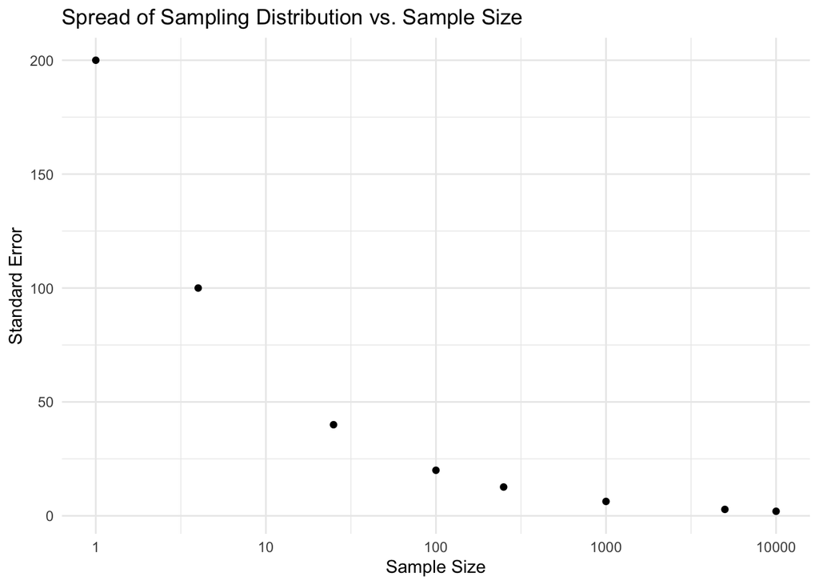

```r
SSE <- c(200,100,40,20,12.6491106,6.3245553,2.8284271,2)
SSize <- c(1, 4, 25, 100, 250, 1000, 5000, 10000)

data1 <- data.frame(SSize, SSE)

Graph1 <- ggplot (data1, aes(x = SSize, y = SSE))+
  geom_point() +
  scale_x_log10()+
   labs(
    title = "Spread of Sampling Distribution vs. Sample Size",
    x = "Sample Size",
    y = "Standard Error"
  ) +
  theme_minimal()

Graph1
```

## Question 3

*Points: 4*

**Note**

4/4

Suppose you conduct a survey (to generate a sample mean of interest) and find that it has a margin of error of 4.5 with a sample size of 900 using a 95% confidence interval. What would the margin of error be for a 90% confidence interval?

```r
(4.5/1.96) * 30
```

```
[1] 68.87755
```

```r
1.645*68.87755/sqrt(900)
```

```
[1] 3.776786
```

Since 4.5 = Z * σ/ sqrt(900), which means σ = (4.5/1.96) * 30 = 68.87755

Z for 90% confidence interval is 1.645, then the new margin of error is 1.645*68.87755/sqrt(900), so the answer is 3.776786

## Question 4

*Points: 4*

Assume that, in State A, the mean income in the population is $20,000 with a standard deviation of $2,000. If you took an SRS of 900 individuals from that population, what is the probability that you would get a sample mean income of $20,200 or greater? What would be the probability if the sample size was only 25?

```r
2000/ sqrt(900)
```

```
[1] 66.66667
```

```r
(20200 - 20000)/66.66667
```

```
[1] 3
```

```r
1 - 0.99865
```

```
[1] 0.00135
```

```r
2000/ sqrt(25)
```

```
[1] 400
```

```r
(20200 - 20000)/400
```

```
[1] 0.5
```

```r
1 - 0.6915
```

```
[1] 0.3085
```

The SE in size of 900 is 66.66667, with the smaple mean of 20200, then Z score is (20200 - 20000)/66.66667 = 3. In a normal distribution, when Z >= 3, the probability is 1 − 0.99865 = 0.00135.

**Note**

Assume a normal distribution for both questions.

## Question 5

*Points: 4*

**Note**

4/4

Assume that a coin is fair. If I flip a coin 500 times, what is a 95% confidence interval for the range of the count of heads that I will get? What if I flip the coin 5,000 times? What about 50,000 times?

the possibility of a fair coin with head is 0.5, the distribution of range of the count of heads is a normal distribution.

```r
(0.5 + 1.96 * sqrt(0.5 * (1- 0.5) / 500)) * 500
```

```
[1] 271.9135
```

```r
(0.5 - 1.96 * sqrt(0.5 * (1- 0.5) / 500)) * 500
```

```
[1] 228.0865
```

```r
(0.5 + 1.96 * sqrt(0.5 * (1- 0.5) / 5000)) * 5000
```

```
[1] 2569.296
```

```r
(0.5 - 1.96 * sqrt(0.5 * (1- 0.5) / 5000)) * 5000
```

```
[1] 2430.704
```

```r
(0.5 + 1.96 * sqrt(0.5 * (1- 0.5) / 50000)) * 50000
```

```
[1] 25219.13
```

```r
(0.5 - 1.96 * sqrt(0.5 * (1- 0.5) / 50000)) * 50000
```

```
[1] 24780.87
```